# Tutorial 9

# Libraries

```r
library(magrittr)
library(dplyr)
library(mgcv)
```

# Question 1

To develop a statistical model that allows the estimation of body fat for men using only a scale and a measuring tape, a sample of 252 men was surveyed, with their bodyfat (%), age (yr), weight (lbs) and wrist circumference (cm) collected in the dataset bodyfat.csv.

```r
bfd <- read.csv("/Users/jasonchan/MSTAT/STAT6014_Advanced_Stat_Model/Tutorial codes/Tutorial9/bodyfat.csv")

head(bfd)
```

|  | bodyfat | age | weight | wrist |
| --- | --- | --- | --- | --- |
| 1 | 12.3 | 23 | 154.25 | 17.1 |
| 2 | 6.1 | 22 | 173.25 | 18.2 |
| 3 | 25.3 | 22 | 154.00 | 16.6 |
| 4 | 10.4 | 26 | 184.75 | 18.2 |
| 5 | 28.7 | 24 | 184.25 | 17.7 |
| 6 | 20.9 | 24 | 210.25 | 18.8 |

## Part (a)

Fit a nonparametric regression function to predict bodyfat from weight, using smoothing spline.

```r
# Fit smoothing spline of bodyfat on weight,
# with smoothing parameter selected based on GCV
spfit <- smooth.spline(bfd$weight, bfd$bodyfat, cv = FALSE)
spfit
```

```
Call:
smooth.spline(x = bfd$weight, y = bfd$bodyfat, cv = FALSE)

Smoothing Parameter  spar= 1.20415  lambda= 0.04169039 (14 iterations)
Equivalent Degrees of Freedom (Df): 3.293615
Penalized Criterion (RSS): 8260.729
GCV: 43.14513
```

```r
# Plot the fitted regression line
plot(bfd$weight, bfd$bodyfat, pch = 20, cex = 0.8,
     main = "Cubic smoothing spline fit for Bodyfat data",
     xlab = "Weight (lb)", ylab = "Bodyfat (%)")
lines(spfit, col = "blue", lwd=2)
```

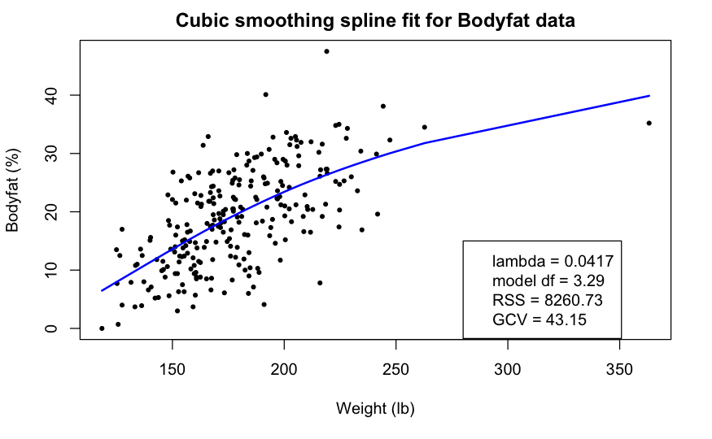

```r
info <- c(paste0("lambda = ",round(spfit$lambda,4)),
          paste0("model df = ",round(spfit$df,2)),
          paste0("RSS = ",round(spfit$pen.crit,2)),
          paste0("GCV = ",round(spfit$cv.crit,2)))
legend(280, 15, info)
```

## Part (b)

Fit an additive model to predict bodyfat from all the other variables.

```r
# Fit additive model
bf.gam1 <- gam(bodyfat ~ s(age) + s(weight) + s(wrist), data = bfd)
summary(bf.gam1)
```

```
Family: gaussian
Link function: identity

Formula:
bodyfat ~ s(age) + s(weight) + s(wrist)

Parametric coefficients:
            Estimate Std. Error t value Pr(>|t|)
(Intercept)   19.151      0.345   55.51   <2e-16 ***
---
Signif. codes:  0 ‘***’ 0.001 ‘**’ 0.01 ‘*’ 0.05 ‘.’ 0.1 ‘ ’ 1

Approximate significance of smooth terms:
            edf Ref.df     F  p-value
s(age)    1.285  1.516 55.19 1.02e-15 ***
s(weight) 3.248  4.031 57.75  < 2e-16 ***
s(wrist)  2.640  3.379 15.09 1.06e-09 ***
---
Signif. codes:  0 ‘***’ 0.001 ‘**’ 0.01 ‘*’ 0.05 ‘.’ 0.1 ‘ ’ 1

R-sq.(adj) =  0.572   Deviance explained = 58.4%
GCV = 31.005  Scale est. = 30        n = 252
```

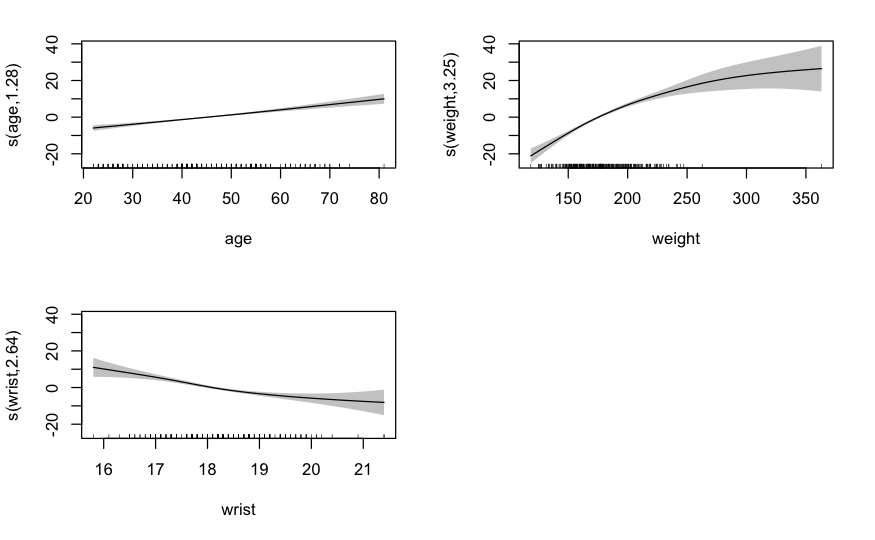

```r
# Construct fit plots for Model 1
plot(bf.gam1, pages = 1, se = TRUE, shade = TRUE)
```

- Age seems like a good candidate for a linear relationship

## Part (c)

Refine the model in part (b) if there is any linear relationship revealed.

```r
## Q1.c
# Fit partial linear additive model (Model 2),
# with age as linear component
bf.gam2 <- gam(bodyfat ~ age + s(weight) + s(wrist), data = bfd)
summary(bf.gam2)
```

```
Family: gaussian
Link function: identity

Formula:
bodyfat ~ age + s(weight) + s(wrist)

Parametric coefficients:
            Estimate Std. Error t value Pr(>|t|)
(Intercept)  7.28142    1.35194   5.386 1.69e-07 ***
age          0.26444    0.02912   9.081  < 2e-16 ***
---
Signif. codes:  0 ‘***’ 0.001 ‘**’ 0.01 ‘*’ 0.05 ‘.’ 0.1 ‘ ’ 1

Approximate significance of smooth terms:
            edf Ref.df     F  p-value
s(weight) 3.249  4.032 57.73  < 2e-16 ***
s(wrist)  2.623  3.359 15.11 1.11e-09 ***
---
Signif. codes:  0 ‘***’ 0.001 ‘**’ 0.01 ‘*’ 0.05 ‘.’ 0.1 ‘ ’ 1

R-sq.(adj) =  0.571   Deviance explained = 58.3%
GCV = 31.012  Scale est. = 30.043    n = 252
```

## Deviance Test

```r
# Compare Model 2 to Model 1 by Chi-square test
anova(bf.gam2, bf.gam1, test = "Chisq")
```

```
Analysis of Deviance Table

Model 1: bodyfat ~ age + s(weight) + s(wrist)
Model 2: bodyfat ~ s(age) + s(weight) + s(wrist)
  Resid. Df Resid. Dev      Df Deviance Pr(>Chi)
1    242.61     7334.4
2    242.07     7314.7 0.53491   19.658   0.2303
```

- Model 2 is not significantly different from model 1 in terms of deviance
- Wrist also seems like a good candidate for a linear relationship

## Model 3, age, wrist as linear component

```r
# Fit partial linear additive model (Model 3),
# with age and wrist as linear component
bf.gam3 <- gam(bodyfat ~ age + wrist + s(weight) , data = bfd)
summary(bf.gam3)
```

```
Family: gaussian
Link function: identity

Formula:
bodyfat ~ age + wrist + s(weight)

Parametric coefficients:
            Estimate Std. Error t value Pr(>|t|)
(Intercept) 79.31796   10.34353   7.668 4.04e-13 ***
age          0.26296    0.02941   8.940  < 2e-16 ***
wrist       -3.94793    0.58665  -6.730 1.19e-10 ***
---
Signif. codes:  0 ‘***’ 0.001 ‘**’ 0.01 ‘*’ 0.05 ‘.’ 0.1 ‘ ’ 1

Approximate significance of smooth terms:
            edf Ref.df     F p-value
s(weight) 2.818  3.531 63.85  <2e-16 ***
---
Signif. codes:  0 ‘***’ 0.001 ‘**’ 0.01 ‘*’ 0.05 ‘.’ 0.1 ‘ ’ 1

R-sq.(adj) =  0.561   Deviance explained = 56.9%
GCV = 31.471  Scale est. = 30.745    n = 252
```

## Deviance Test of Model 2 and Model 3

```r
# Compare Model 3 to Model 2 by Chi-square test
anova(bf.gam3, bf.gam2, test = "Chisq")
```

```
Analysis of Deviance Table

Model 1: bodyfat ~ age + wrist + s(weight)
Model 2: bodyfat ~ age + s(weight) + s(wrist)
  Resid. Df Resid. Dev     Df Deviance Pr(>Chi)
1    245.47     7568.8
2    242.61     7334.4 2.8604   234.42    0.045 *
---
Signif. codes:  0 ‘***’ 0.001 ‘**’ 0.01 ‘*’ 0.05 ‘.’ 0.1 ‘ ’ 1
```

- Model 3 is significantly different from model 2. Non linearity of wrist cannot be ignored
- Model 2 is chosen as final model

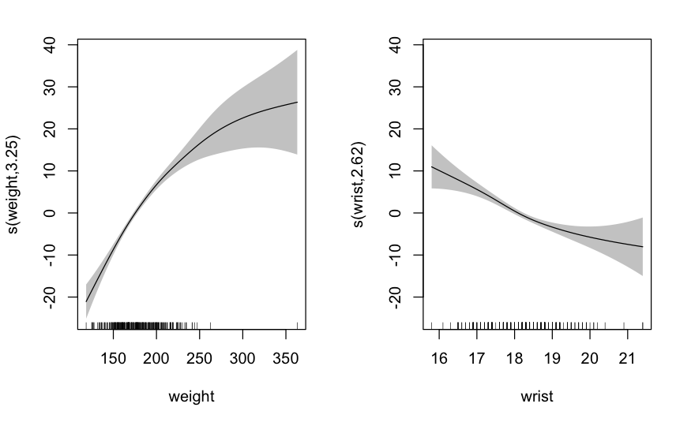

```r
# Construct fit plots for Model 2
plot(bf.gam2, pages = 1, se = TRUE, shade = TRUE)
```

## Prediction

```r
# Predict the bodyfat of a 50 yrs old man
# whose weigh 210 lbs and wrist circumference 15 cm
predict(bf.gam2, newdata = data.frame(age = 50, weight = 210, wrist = 15))
```

```
       1
43.95245
```

- Always start by fitting all regressors as additive, then look at summary and partial plot
- Continue refining and checking deviance

Final model is then model 2 and is fitted as:

$$\hat{µ} = 7.2814 + 0.2644 age + s_1(weight) + s_2(wrist)$$